# Exploratory Analysis

## The Wealth-Wellness Connection

### Authors

Tyler Vuu tvuu@uw.edu  
Olivia Qi qq2002qq@uw.edu  
Carson Sharpe carson02@uw.edu  
Bao Ngan Doan bndoan2@uw.edu

### Date

Winter 2023

## Abstract

For our project, our main question focuses on the differing factors on the nutritional intake of people within the United States and to address this question we will be looking at different factors and comparing them to nutrients levels being ingested. We are concerned with this because of the rampant obesity crisis in America and through this research, we will hopefully be able to see whether there is a correlation with income level. Through our research and cross examination, we will hopefully be able to target and come up with more effective strategies to combat obesity.

## Keywords

Health, income, nutrition, obesity, age

## Proposal

1. Introduction

We believe that in the USA, there is a major nutrition crisis. Though America is often considered to be one of the wealthiest countries in the world, many people suffer from diet-related health problems such as obesity, heart disease, and type 2 diabetes. Our project aims to analyze the link between nutrition compared to other aspects of a person’s life. We will examine the data through the lens of three key questions.

(Q1)The first is focused on how income levels affect overall nutritional health for people within the United States. This is important because there is a prevalent wealth gap in the USA, and see how that pertains to nutrition.

(Q2) Our second question is, looking at how different genders impact income or nutrition levels. This is important because gender discrimination is evident across industries and has been proven to influence women’s income.

(Q3) Additionally, it will be important to view what other lifestyle-related factors, such as physical activity or smoking frequency correlate to health and income.

Because there are a number of confounding variables related to health and nutrition, it is important to separate the impact of income from other factors such as age, genetics, and lifestyle. By answering these three questions, we will better understand the connection between income, gender, lifestyle, and health. This can help inform public health policies focused on improving the nutrition and health of people in the United States.

2. Related Work

Body Mass Index (BMI) is used as a screening method for weight categories and is correlated with direct measures of body fat. BMI and body fat strongly correlates but two individuals with the same BMI could still differ in body fatness since it also includes their muscle and bone scores. BMI is not used to diagnose or determine the health of an individual but it can be used to help determine if it is a health risk. Another contributing factor is nutrition level and socio-economic status. Studies like the Study of Household Purchasing Patterns, Eating, and Recreation [SHoPPER] have shown associations of poorer quality diets with low household income. Households with a lower socio-economic status are more likely to buy sugary junk food and fewer fruits and vegetables. The quality of foods purchased is strongly associated with an individual’s income, especially if higher quality foods are priced higher than cheap low quality foods. Consistent with existing studies, a study titled “Effect of Socioeconomic Status on Physical and Psychological Health: Lifestyle as a Mediator” revealed that SES had a significant impact on physical health – mainly reflected in three aspects of an individual’s life: occupation, income, and education. It is found that people with higher professional status and income engage in less manual labor, have fewer occasions of being exposed to health rishs, are usually associated with better housing conditions, nutritional status, medical services, etc. These studies were found upon surveys along with a data collection process by staff-trained participants, and can give insight on the metrics in our data as it is used with R to answer our research questions.

References

- Centers for Disease Control and Prevention. (2022, June 3). About adult BMI. Centers for Disease Control and Prevention. Retrieved February 3, 2023, from [https://www.cdc.gov/healthyweight/assessing/bmi/adult_bmi/index.html]
- French, S. A., Tangney, C. C., Crane, M. M., Wang, Y., & Appelhans, B. M. (2019, February 26). Nutrition quality of food purchases varies by household income: The shopper study - BMC public health. BioMed Central. Retrieved February 3, 2023, from [https://bmcpublichealth.biomedcentral.com/articles/10.1186/s12889-019-6546-2]
- Wang, J., & Geng, L. (2019, January 20). Effects of socioeconomic status on physical and psychological health: Lifestyle as a mediator. International journal of environmental research and public health. Retrieved February 3, 2023, from [https://www.ncbi.nlm.nih.gov/pmc/articles/PMC6352250/?fbclid=IwAR2sSqY0TRlOGb-ng_pAFKdmoiod1_isf3mh_axSabycXc8PJNDDjt_T6ZQ#B29-ijerph-16-00281]
3. The Dataset

4. Implications

With the answering of our research question, we will be able to see at which income levels unhealthy diets occur the most and hopefully make them healthier through legislation or school programs. We will also be able to see which nutrients people are lacking or need to consume more of. Policymakers can especially use this data to know where to implement healthy eating programs. Educational policy makers especially could use this data to prioritize which schools need redesigns of their school lunch programs.This information would also benefit the general public as well as they will be able to visualize where their nutritional gaps are. General nutritionists could also use this data to give recommendations to the public on different foods to eat to address these nutritional gaps. Depending on the unhealthiest income bracket, we can also imply where the unhealthiest foods lie price wise and if economically disadvantaged people are also nutritionally disadvantaged as well.

5. Limitations & Challenges

As mentioned previously, the validity of this data could be faulty due to the nature of self-reported data, especially in sensitive areas such as personal health. As we aim to answer the question of, what has the greatest impact on nutrition intake and what impact it has on overall health, it may be challenging to determine which factors indicate an individual’s health level. There are many factors not included in the data related to a person’s lifestyle that may indicate their general health. There may also be some challenges associated with the interpretation of the data since some of the variables could contradict each other, and challenge the validity of our findings. Overall, the challenges are going to be related to the methods we use to analyze and conclude the answer to our question of what has the greatest impact on nutrition intake and what impact it has on overall health.

### Summary Information

This dataset “National Health and Nutrition Examination Survey 2013-2014” had 4418 female and 4243 male participants. Our analysis found the average BMI score to be 29.1534332, with a minimum of 14.1 and a maximum of 82.900002. We also found the average family income to be 7.5119462, which according to the codebook a value of 7 is $35,000 to $44,999, and 8 is $45,000 to $54,9999. With diet also being a category and research point, we found 725 participants out of 8661 total had some sort of special diet, whether that be vegetarian, vegan, weight loss, weight gain, or any other.

### Table

Data Averages grouped by Family Size

| Family Size | Average Family Income | Average BMI | Average BMI Classification |
| --- | --- | --- | --- |
| 1 | 5.12 | 28.83 | 3.01 |
| 2 | 7.88 | 29.25 | 3.08 |
| 3 | 7.65 | 29.30 | 3.08 |
| 4 | 8.53 | 29.00 | 3.04 |
| 5 | 7.81 | 29.27 | 3.09 |
| 6 | 7.47 | 29.40 | 3.18 |
| 7 | 7.31 | 29.51 | 3.08 |

This table was sorted by the family size of participants (1 - 7), finding the average family income, BMI, and BMI classification within each group. Although there are differences between the averages of the other categories, the BMI classifications all come out roughly as 3, which is the overweight value.

### Chart 1

| category | meaning |
| --- | --- |
| 1 | $0 to $4,999 |
| 2 | $5,000 to $9,999 |

One good benchmark of a person’s health is their BMI which is a calculated value based of a persons weight in combination with their height. With the obesity crisis in America, we wanted to see the correlation between income level and average BMI to see if there is a connection between the two.

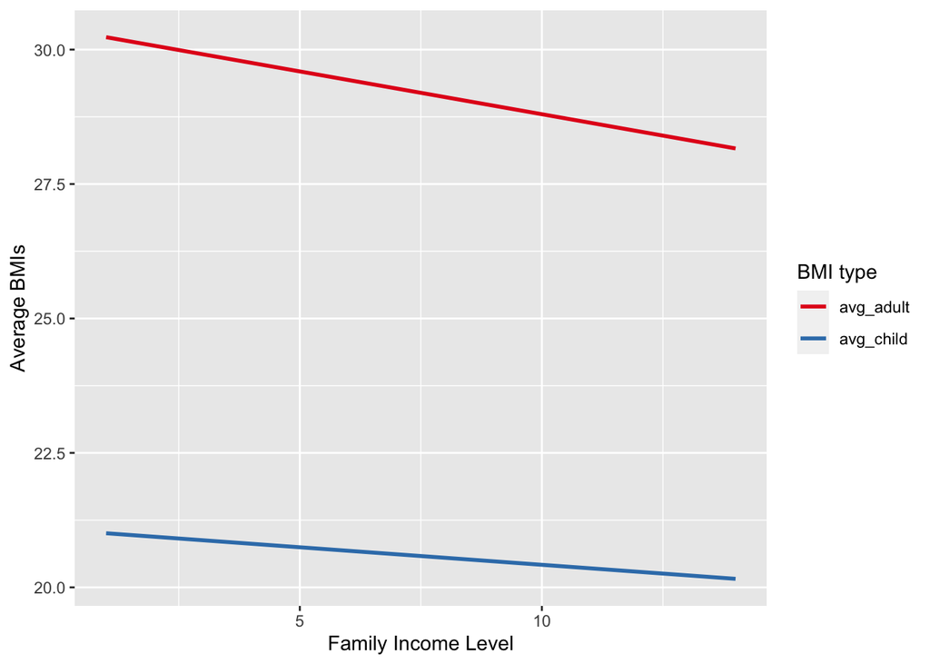

```r
BMI.plot
```

### Chart 2

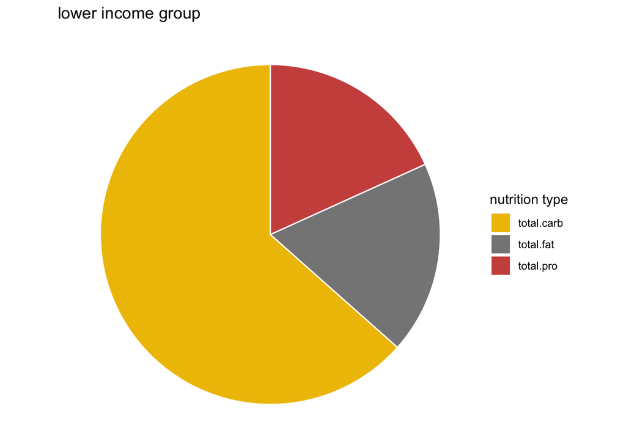

```r
plot1
```

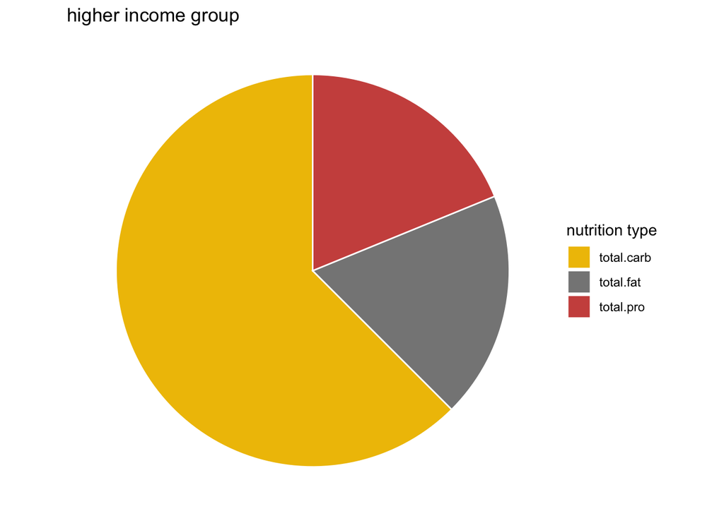

```r
plot2
```

Before plotting, we propose a guess that household income and nutritional intake are closely related. Different foods have different demand and price elasticity. We suspect that when household income is low, people pursue basic carb intake. When people have higher incomes, they make different choices about nutrition to balance their diet.

We use two pie charts to explore the nutrition proportion of each income group. We found that the proportion of three nutrition does not change very much. Even though income increases, carb still takes the biggest proportion. And the proportion of fat and protein also do not vary significantly. We may conclude that carb, fat and protein are necessities for household no matter how much they earn.

### Chart 3

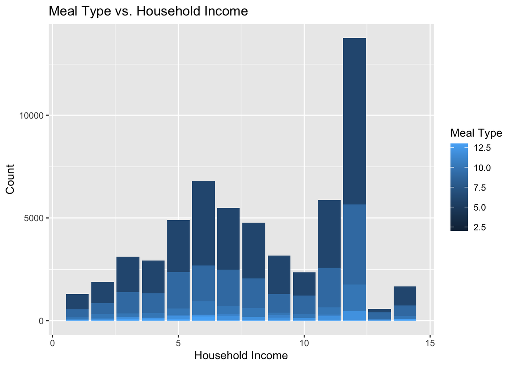

```r
bar_plot
```

This chart is a bar graph of the correlation between types of meals and household income. The reason why we chose to analyze this specific data, in addition to analyzing the correlation between income in nutrition, is because nutrition alone does not tell the full story of an individual’s health. The “types of meals” variable in our data has options ranging from “Breakfast” to “Snack after dinner”. The research question this data answer is “what are the eating habits of people with different income levels?”. We chose to display this data as a bar graph because it offers insight into the number of people who are making these eating choices at different income levels. For example, we can see that the majority of people at a level 6 income level tend to snack after lunch.

| category | meaning |
| --- | --- |
| 1 | Before breakfast |
| 3 | Snack between breakfast and lunch |